# Basic visualisation in R

### Aesthetics in `ggplot2`

In `ggplot2`, the `aes()` - or aesthetics - is where you sore the information to build your plot. These include x and y axis, but also colour, fill (more about that later), grouping, shape, transparency, size.

```
ggplot(data, #your dataframe
       aes(
         x=a, #variable you want on the x axis
         y=b, #variable you want on the y axis
         color=c, #variable that determines outline or point colour
         fill=d, #variable that determines fill colour
         size=e, #variable that determines size
         alpha=f, #variable that determines transparency
         shape=g #variable that determines shape
       ))
```

All other `aes()` variables that are not x and y can either be variables (columns in the dataframe) or can be fixed:

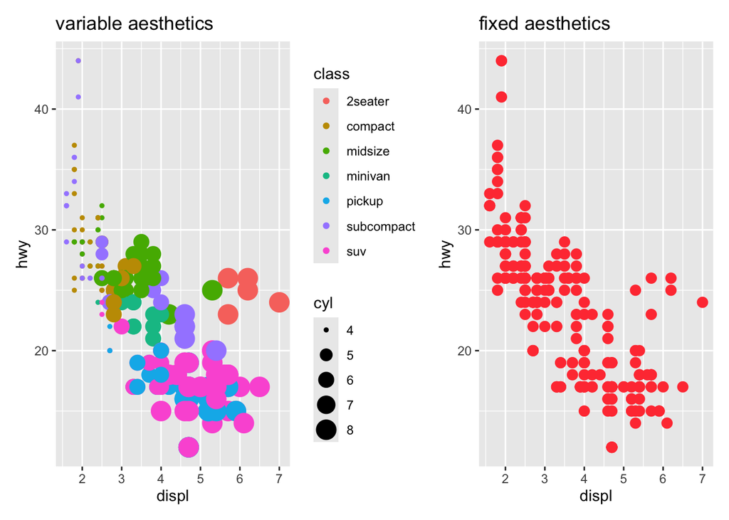

```r
# variable color and size
p1 <- ggplot(mpg, aes(x=displ, y=hwy, color=class, size=cyl)) +
  geom_point() +
  ggtitle("variable aesthetics")
# fixed color and size
p2 <- ggplot(mpg, aes(x=displ, y=hwy)) +
  geom_point(color="brown1", size=3) +
  ggtitle("fixed aesthetics")
p1+p2
```

#### Working with colours

Colour is the second most important factor in your plotting - the first obviously being what kind of plot you choose - because we are wired to intuitively distinguish different colours as having different meaning. This also means that using them incorrectly can lead to difficult or incorrect interpretation of the data. I you take home a single message from this section, let it be that **your palette should be colour blind-friendly and (therefore) have high contrast**.

There are some R packages that allow you to check your plots for colour blindness, such as `colorspace` and `colorblindr`. We won’t use them today, but here is an example:

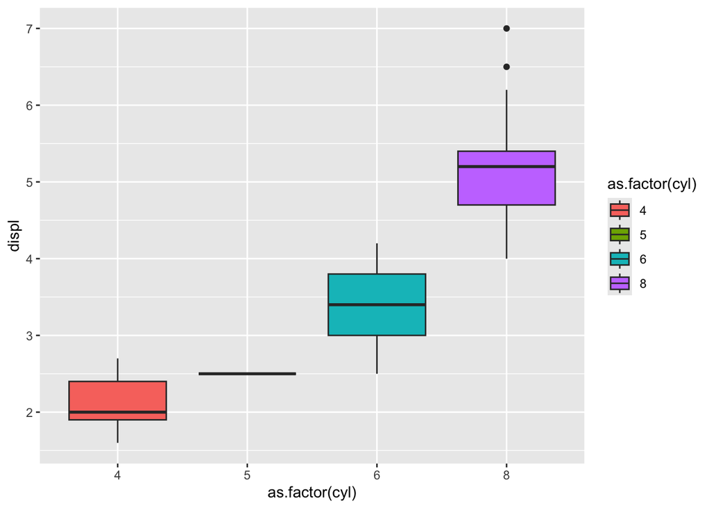

```r
library(colorspace)
library(colorblindr)

# default ggplot colours
p <- ggplot(mpg, aes(x=as.factor(cyl), y=displ, fill=as.factor(cyl))) +
  geom_boxplot()
p
```

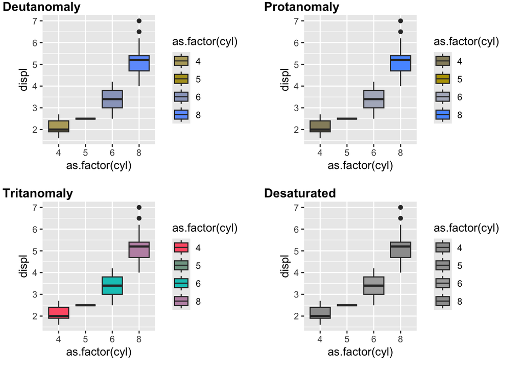

```r
# colourblind rendering
cvd_grid(p)
```

Let’s try a palette with better contrast.

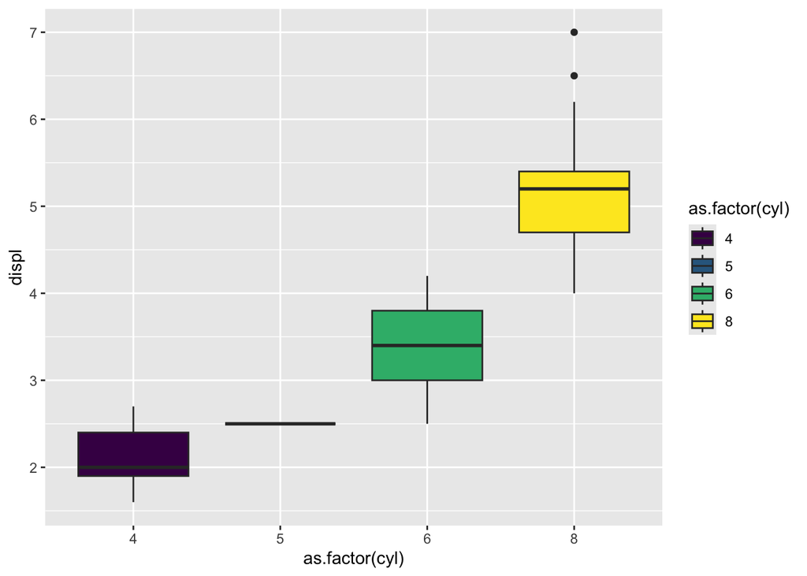

```r
p2 <- ggplot(mpg, aes(x=as.factor(cyl), y=displ, fill=as.factor(cyl))) +
  geom_boxplot() +
  scale_fill_manual(values=viridis(4))
p2
```

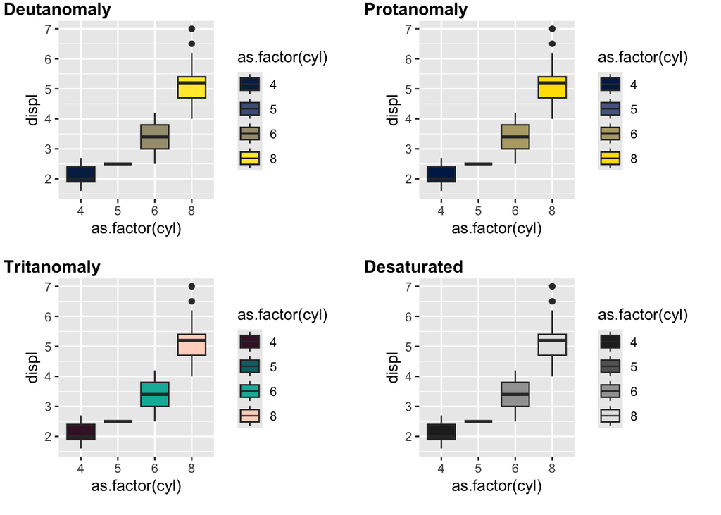

```r
# colourblind rendering
cvd_grid(p2)
```

You can appreciate the power of strong contrast. The `viridis` package used here includes a very nice set of colour blind friendly palettes.

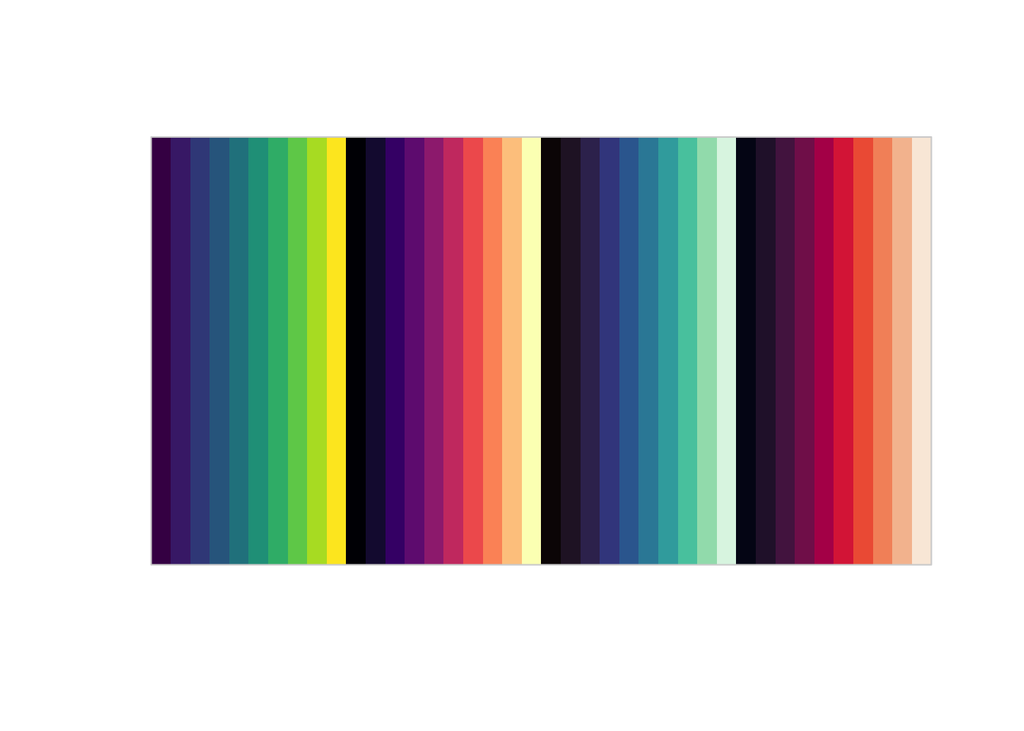

```r
swatchplot(c(
  viridis(10),
  magma(10),
  mako(10),
  rocket(10)
  ), nrow=4)
```

Other nice pre-existing palettes include `cartocolors` and `wesanderson`, but are less flexible in the number of hues they will generate.

In `ggplot2`, `fill` and `color` cover two different aspects and can be modified independently.

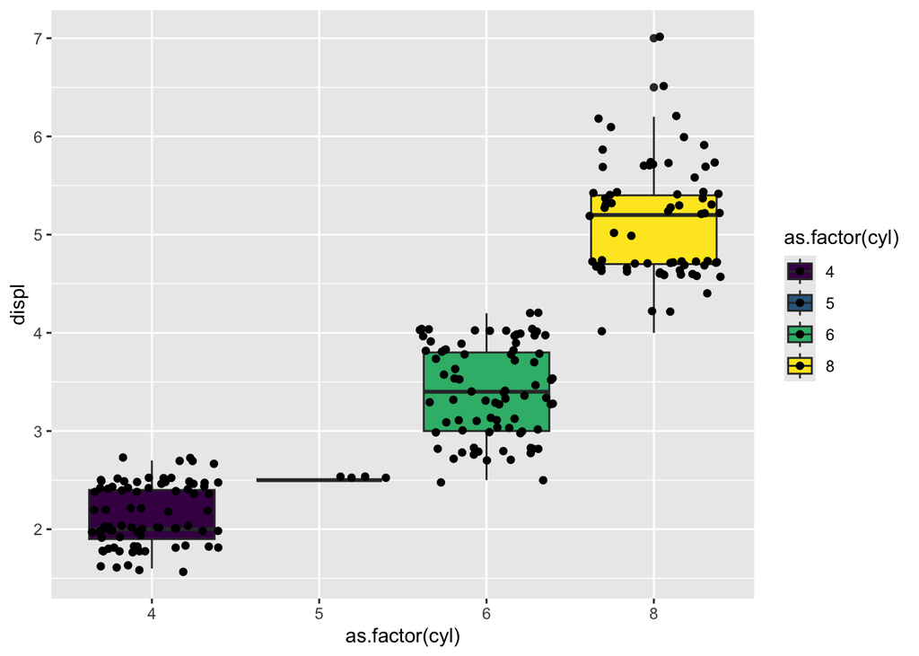

```r
ggplot(mpg, aes(x=as.factor(cyl), y=displ, fill=as.factor(cyl))) +
  geom_boxplot() +
  geom_jitter() +
  scale_fill_manual(values=viridis(4))
```

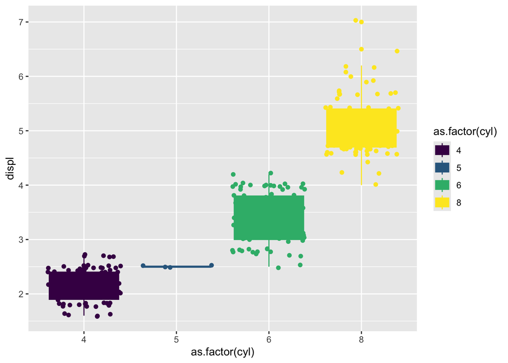

```r
ggplot(mpg, aes(x=as.factor(cyl), y=displ, fill=as.factor(cyl), color=as.factor(cyl))) +
  geom_boxplot() +
  geom_jitter() +
  scale_fill_manual(values=viridis(4)) +
  scale_color_manual(values=viridis(4))
```

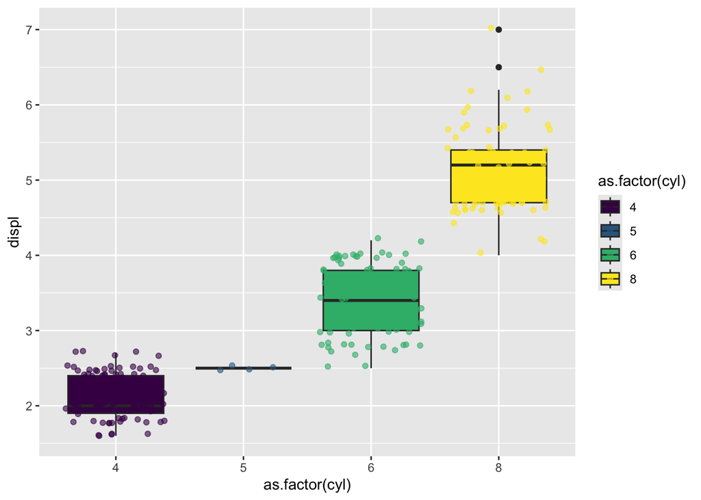

```r
ggplot(mpg, aes(x=as.factor(cyl), y=displ, fill=as.factor(cyl))) +
  geom_boxplot() +
  geom_jitter(aes(color=as.factor(cyl)),alpha=0.6) +
  scale_fill_manual(values=viridis(4)) +
  scale_color_manual(values=viridis(4))
```

There are many ways to set colour scales for either continuous variables or categorical variables, but the most simple to remember for ggplot are `scale_*_continuous` for continuous variables and `scale_*_discrete` for categorical variables. Below two examples:

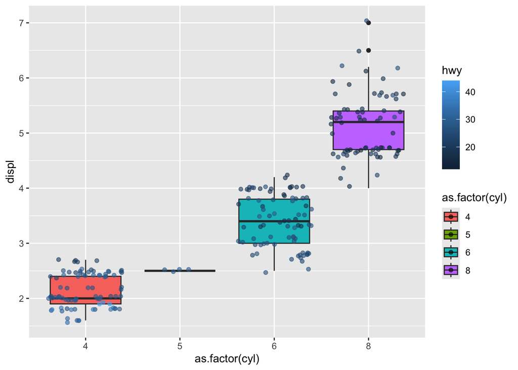

```r
ggplot(mpg, aes(x=as.factor(cyl), y=displ, fill=as.factor(cyl))) +
  geom_boxplot() +
  geom_jitter(aes(color=hwy),alpha=0.6) +
  scale_fill_discrete() +
  scale_color_continuous()
```

We can obviously choose the palettes we want to use:

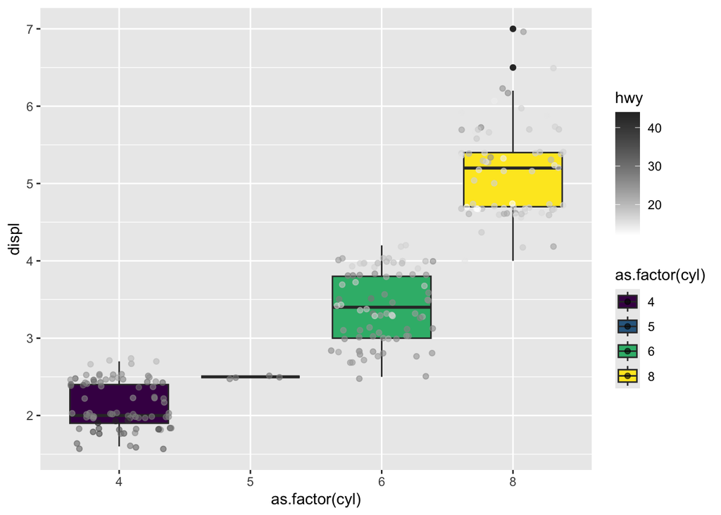

```r
ggplot(mpg, aes(x=as.factor(cyl), y=displ, fill=as.factor(cyl))) +
  geom_boxplot() +
  geom_jitter(aes(color=hwy),alpha=0.6) +
  scale_fill_manual(values=viridis(4)) +
  scale_color_gradient(low="white", high="grey18")
```

##### AVOID: Bidirectional colour scales for unidirectional data

Let’s make toy RNA-seq-like datasets to demonstrate this.

```r
# unidirectional data
Dir1 <- data.frame(
  "FPKM" = c(5, 10, 20, 40, 60, 80, 100, 120),
  "Gene" = 1:8
)
# bidirectional data
Dir2 <- data.frame(
  "log2FC" = c(-10, -4, -2, 0, 2, 4, 10),
  "Gene" = 1:7
)
```

These are good examples of use of colour scales:

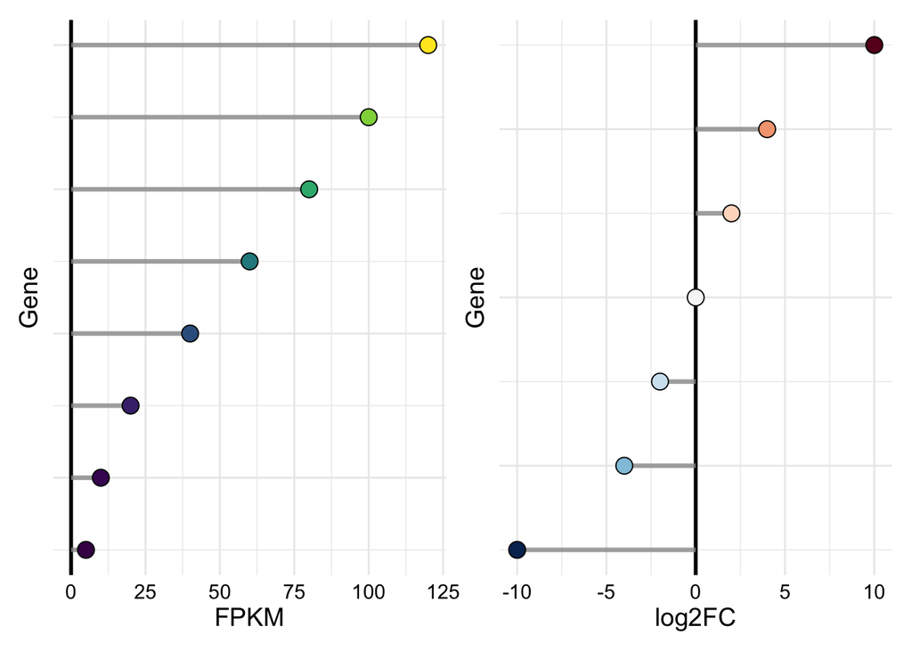

#### Size (and shape) sometimes matters

how size can add an additional scalar measurement on top of colour how shape can add another categorical variable on top of colour

## Main types of plots you are likely to use

### Dot plot

#### Scatter plot

##### Lion’s Q: How to best visualise bulk RNA-seq?

My opinion: MA plots, volcano plots, expression scatterplots.

#### Linking point with a line

### Bar plot

#### Proportion stacked bar plots instead of pie charts

Humans do not intuitively understand angle-based differences

##### AVOID: Bar plots for means separation

##### AVOID: Confusing position-based viz with length-based viz

##### AVOID: Not checking the data range at each factor level

### Violin plot

##### AVOID: Violin plots for small sample sizes

### Heatmap

##### AVOID: Unclustered heatmaps

##### AVOID: Heatmaps without checking for outliers

## Composite plots

### Faceting avoids overwhelming “meadows”

### Violin plot with boxplot inside

You get information on both mean and distribution

### Adding data points to other plots

### Fitting smoothened lines to plots

### Adding statistical information

Error bars, mean, median, etc.